# Assignment 4

Simple Linear Models

Author

Dr. Alejandro Molina-Moctezuma

# Linear Models with Categorical Data

In this assignment, we will run linear models with categorical data, check assumptions, and connect linear models to the t-tests you have heard about. By the end of this assignment, you should understand how to check assumptions, interpret model output, and run t-tests both “by hand” (using the equation) and with the built-in R function.

## One categorical group: Linear model and assumptions

So far we have talked about many types of linear models. Now is the time to test them. The first model you will run is a linear model with no covariates (similar to a one-sample t-test):

$$\begin{split}y_i & \sim \beta_0 + \epsilon_i \\
\text{where } \epsilon & \sim normal(0,\sigma)
\end{split}$$

Where $y_i$ is the response variable, $\beta_0$ is the intercept (and mean), and $\epsilon$ is the residual (or observer) error.

Example 1 🐁

The Jackson Laboratory (Bar Harbor, ME) shipped you some lab mice 🐁 from the C57BL/6J strain. You chose this specific strain because they are supposed to have vey low mass variability, and their mean mass at 20 weeks is 20.2 grams, which is important for your experiments. However, you suspect the mice you got might have a different weight, so, you take a random sample of 21 individuals to check.

Step 1: Download the “mousedata.csv” file and load it in an object named mousedata and inspect it

```r
mousedata<-read.csv("mousedata.csv")
mousedata<-mousedata$x
mousedata
```

```
 [1] 18.41489 17.96535 20.23447 16.91896 19.21828 25.28136 17.35877 18.97449
 [9] 21.58163 16.26229 18.40497 20.59939 19.41167 20.00668 18.53189 17.06733
[17] 19.18580 22.53532 21.62798 20.19551 19.47198
```

Before we run any model, we need to check the **assumptions** of a linear model. Remember, there are four main assumptions:

1. **Independence** — we assume the observations are independent of each other (we won’t test this one; it’s a design issue)
2. **Normality** — the residuals should be normally distributed
3. **Homogeneity of variance** (homoscedasticity) — the variance of the residuals should be constant
4. **Linearity** — the relationship between the response and the predictor should be linear (for categorical data, this is usually met)

We will check assumptions 2 and 3 (and linearity when applicable). Let’s first run the model, and then check the assumptions using diagnostic plots.

```r
#mdata<-as.data.frame(mousedata)
model1<-lm(mousedata~1)
```

#### Checking Normality with a QQ-plot

A QQ-plot (quantile-quantile plot) compares the quantiles of our residuals against the theoretical quantiles of a normal distribution. If our residuals are normally distributed, the points should fall approximately along the diagonal line.

I will use the qqplotr package, but you can also plot this using the base R function `qqnorm` and `qqline`. If you want to use the base R functions, you can do it like this:

```r
#run qqplot
qqnorm(resid(model1))
qqline(resid(model1))
```

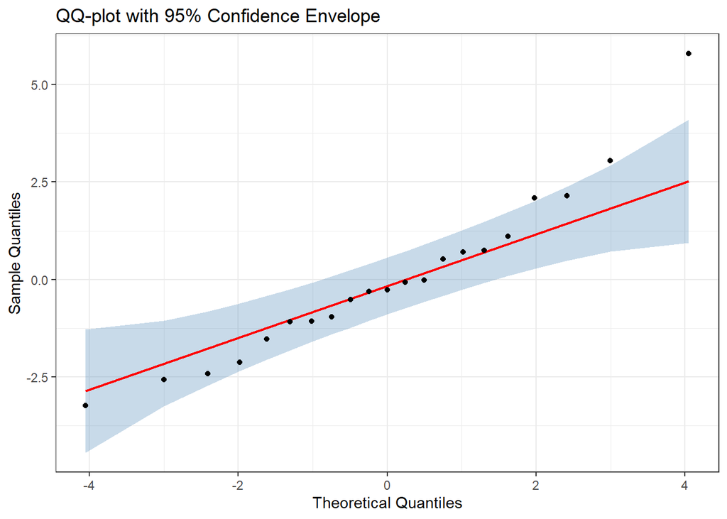

```r
#Run this in ggplot using the qqplot function, with a confidence envelope
library(ggplot2)
library(qqplotr)
model1_resid <- data.frame(residuals = resid(model1))

ggplot(model1_resid, aes(sample = residuals)) +
  stat_qq_band(alpha = 0.3, fill = "steelblue") +
  stat_qq_line(color = "red") +
  stat_qq_point() +
  labs(title = "QQ-plot with 95% Confidence Envelope",
       x = "Theoretical Quantiles",
       y = "Sample Quantiles") +
  theme_bw()
```

#### Checking Homogeneity of Variance (Residuals vs. Fitted)

We plot the residuals against the fitted (predicted) values. If the assumption is met, we should see a random cloud of points with no obvious pattern. The spread of the residuals should be roughly constant across the fitted values.

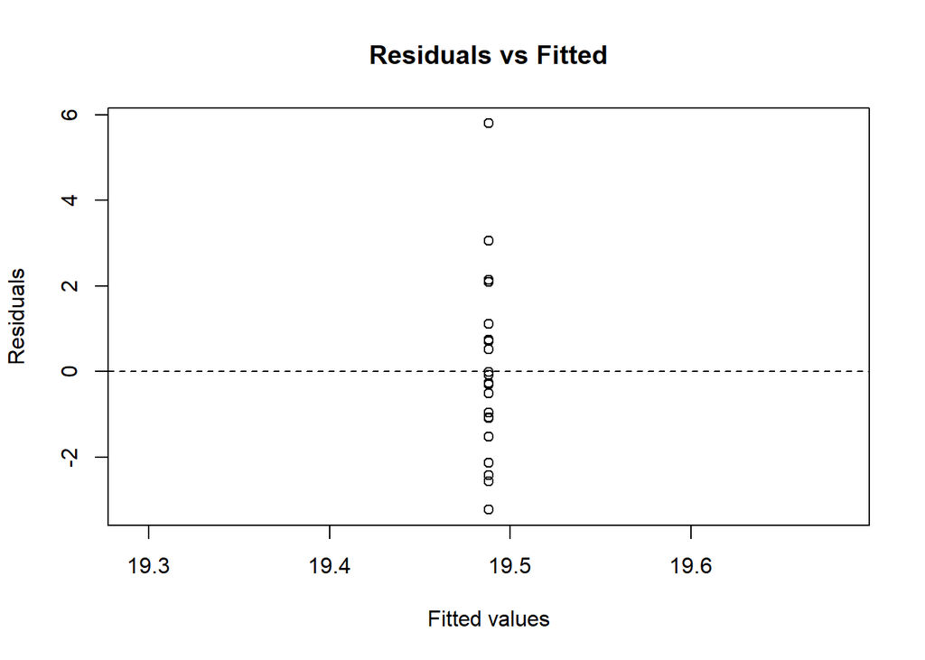

```r
plot(fitted(model1), resid(model1), xlab="Fitted values", ylab="Residuals", main="Residuals vs Fitted")
abline(h=0, lty="dashed")
```

**Q1. 2pts ✏️**

Look at both diagnostic plots. Do the assumptions of normality and homogeneity of variance seem to be met? Explain what you see in each plot. Remember, this is not a test that you pass or fail, so, you can have some nuance here.

the question is: is the average mass of your mice equal to 20.2 grams?

The relevant hypotheses would be:

- $$Ho : \mu_1 = 20.2$$
- $$Ha : \mu_1 \neq 20.2$$

And our model looks like:

$$y_i = \beta_0 + \epsilon_i \ \ \ \ \ \text{where} \ \ \ \ \ \epsilon_i \sim \text{N}(0,\sigma)$$

where $\beta_0$ represents the estimated $\mu_1$

However, the model above is not testing our null hypothesis. Remember, we are wondering whether the mean mass of our mice is equal to 20.2 grams! In order to test that, we subtract the hypothesized value:

```r
model1alternative<-lm(mousedata-20.2~1)
summary(model1alternative)
```

```
Call:
lm(formula = mousedata - 20.2 ~ 1)

Residuals:
    Min      1Q  Median      3Q     Max
-3.2258 -1.0831 -0.2698  0.7464  5.7933

Coefficients:
            Estimate Std. Error t value Pr(>|t|)
(Intercept)  -0.7120     0.4571  -1.557    0.135

Residual standard error: 2.095 on 20 degrees of freedom
```

**Q2. 1pt ✏️**

Interpret the output of `model1alternative`. What is the estimate of $\beta_0$? What does the p-value tell you? Do you reject or fail to reject the null hypothesis?

### The one-sample t-test: by hand

The t-test is simply a specific case of the linear model! The equation for the one-sample t-statistic is:

$$t = \frac{\bar{x} - \mu_0}{SE} = \frac{\bar{x} - \mu_0}{\frac{s}{\sqrt{n}}}$$

Where $\bar{x}$ is the sample mean, $\mu_0$ is the hypothesized mean (20.2), $s$ is the sample standard deviation, and $n$ is the sample size.

You have all the tools you need. Here are the functions:

- `mean()` — to estimate the sample mean
- `sd()` — to estimate the sample standard deviation
- `length()` — to get the sample size
- `sqrt()` — for the square root

**Q3. 2pts ✏️**

Using the equation above and the R functions listed, estimate the t-statistic for the one-sample t-test by hand (in R). Show your code and report the t-value you obtained.

Then, obtain the p-value from that t-statistic using the following function:

```r
2*pt(abs(your_t_value), df=length(mousedata)-1, lower.tail=FALSE)
```

(Replace `your_t_value` with the t you calculated). The `pt` function gives us the probability from a t-distribution. We multiply by 2 because this is a two-tailed test. Compare this p-value with the one you got from the linear model.

Now, let’s confirm our results using the built-in `t.test` function:

```r
t.test(mousedata,mu=20.2)
```

```
    One Sample t-test

data:  mousedata
t = -1.5575, df = 20, p-value = 0.135
alternative hypothesis: true mean is not equal to 20.2
95 percent confidence interval:
 18.53451 20.44159
sample estimates:
mean of x
 19.48805
```

**Q4. 1pt ✏️**

Compare the t-statistic and p-value you calculated by hand with the output from `t.test`. Are they the same? How does the output compare with the linear model?

## Categorical: two groups

We will work with the teporingos 🐇 example. But you can rename the examples and imagine they represent any other type of response variables.

In this case, we are exploring two populations and wondering whether they are different in size.

The relevant hypotheses would be:

- $$Ho : \mu_1 = \mu_2$$
- $$Ha : \mu_1 \neq \mu_2$$

First, we read the data:

```r
teporingos<-read.csv("teporingos2pops.csv")
```

Now, let’s plot it. We will use `ggplot`. Remember we need to load it:

```r
library(ggplot2)
```

We used ggplot for a previous assignment. If you are curious about it, this is how ggplot works:

$$\underbrace{ggplot}_{initiate\; plot}(\underbrace{data = df}_{data\;frame},\; \underbrace{aes(x =\; , y = \;)}_{plot\; attributes}) + \underbrace{geom\_line()}_{geometry\:line} + \underbrace{geom\_point()}_{geometry\:point} + \underbrace{theme()}_{customize}$$

In that example we have two geometries. So, in that case we would be plotting lines and points (easy, right?). If you want to see all the available geometries, visit: https://ggplot2.tidyverse.org/reference#geoms

Now, let’s plot the data. I am providing the code, but in the future, you will be writing the code:

This is a “violin plot” which shows the data distribution. We will see different plots during this class.

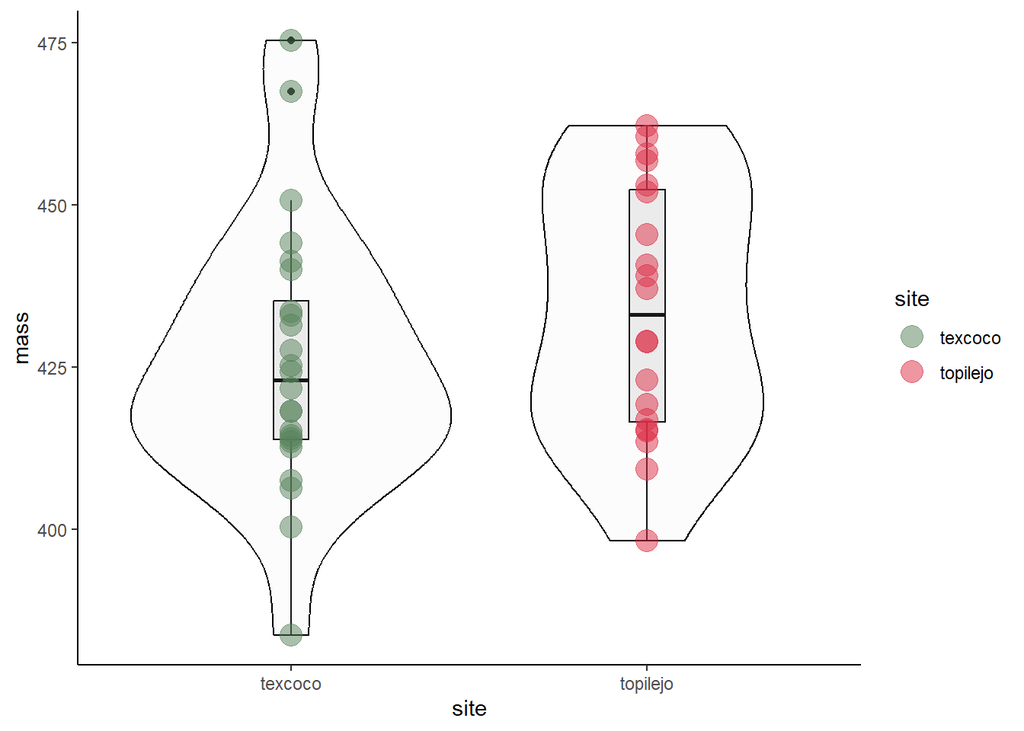

```r
ggplot(data = teporingos, aes(x = site, y = mass)) +
  geom_boxplot(fill=gray(0.7,0.25),color="black",width=0.1) +
  geom_violin(fill=gray(0.9,0.1),color="black")+
 theme_bw() + theme(panel.border = element_blank(), panel.grid.major = element_blank(),
                     panel.grid.minor = element_blank(), axis.line = element_line(colour = "black"))+
  geom_point(aes(color = site), size = 5, alpha = 0.5)+
  scale_color_manual(values=c("#57825a","#dd2e46"))
```

Let’s run the linear model:

$$y_i = \beta_0 + \beta_1x_{1,i} + \epsilon_i \ \ \ \ \ \text{where} \ \ \ \ \ \epsilon_i \sim \text{N}(0,\sigma)$$

Where $x_1$ (population) is treated as:

| population | Value of $x_1$ |
| --- | --- |
| Texcoco | 0 |
| Topilejo | 1 |

```r
model2<-lm(mass~site, data=teporingos)
```

#### Checking assumptions

Let’s check the assumptions for this model too:

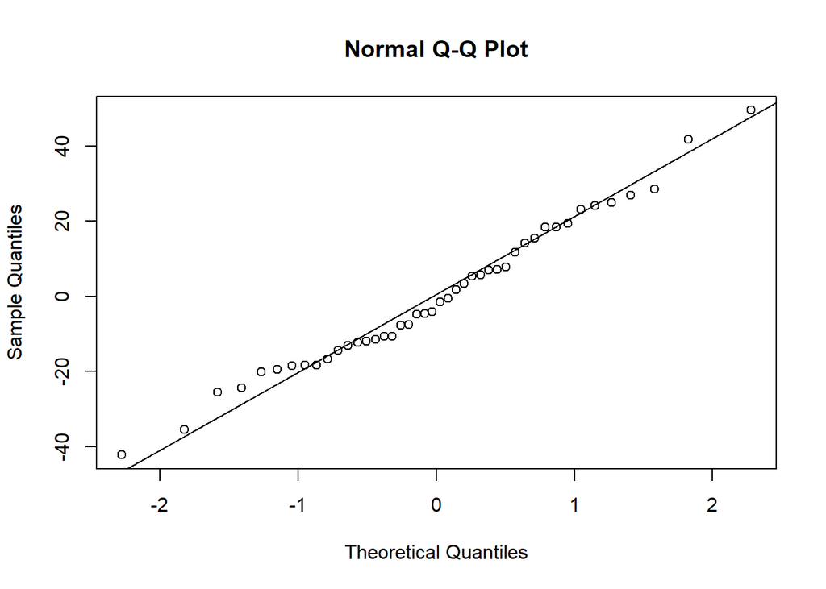

```r
qqnorm(resid(model2))
qqline(resid(model2))
```

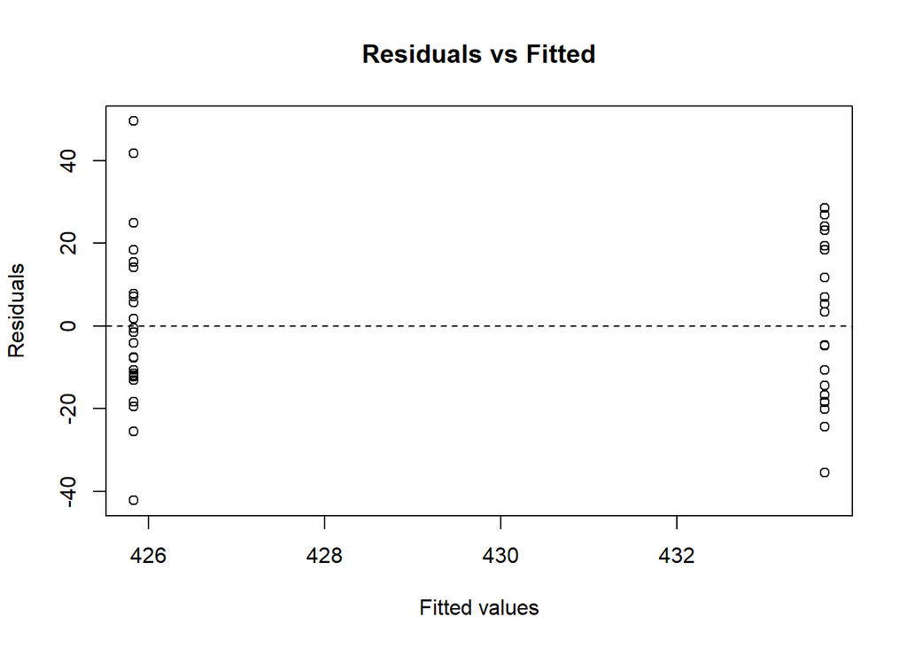

```r
plot(fitted(model2), resid(model2), xlab="Fitted values", ylab="Residuals", main="Residuals vs Fitted")
abline(h=0, lty="dashed")
```

**Q5. 1pt ✏️**

Do the assumptions appear to be met for this model? Briefly explain.

Now let’s look at the model output:

```r
summary(model2)
```

```
Call:
lm(formula = mass ~ site, data = teporingos)

Residuals:
   Min     1Q Median     3Q    Max
-42.18 -13.43  -2.84  14.51  49.50

Coefficients:
             Estimate Std. Error t value Pr(>|t|)
(Intercept)   425.834      4.095 103.993   <2e-16 ***
sitetopilejo    7.839      6.074   1.291    0.204
---
Signif. codes:  0 '***' 0.001 '**' 0.01 '*' 0.05 '.' 0.1 ' ' 1

Residual standard error: 20.06 on 42 degrees of freedom
Multiple R-squared:  0.03815,   Adjusted R-squared:  0.01525
F-statistic: 1.666 on 1 and 42 DF,  p-value: 0.2039
```

Let’s look at the equation that you just ran, but let’s replace the variable names.

$$\begin{split}
Mass_i & \sim \beta_0 + \beta_1(\text{population}) + \epsilon_i \\
\text{where } \epsilon & \sim normal(0,\sigma)
\end{split}$$

So, for Texcoco, we can obtain the predicted value as:

$$\begin{split}
y_i & \sim \beta_0 + \epsilon_i \\
\text{where } \epsilon & \sim normal(0,\sigma)
\end{split}$$

While for the Topilejo individuals, the predicted value is obtained using the following:

$$\begin{split}
y_i & \sim \beta_0 + \beta_1+ \epsilon_i \\
\text{where } \epsilon & \sim normal(0,\sigma)
\end{split}$$

**Q6. 1pt ✏️**

Interpret the model output. What does $\beta_0$ represent? What does $\beta_1$ represent? Is there a significant difference between the two populations?

### The two-sample t-test (equal variance): by hand

Just like the one-sample t-test, the two-sample t-test assuming equal variances has its own equation:

$$t = \frac{\bar{x}_1 - \bar{x}_2}{s_p\sqrt{\frac{1}{n_1}+\frac{1}{n_2}}}$$

Where $s_p$ is the pooled standard deviation:

$$s_p = \sqrt{\frac{(n_1-1)s_1^2 + (n_2-1)s_2^2}{n_1+n_2-2}}$$

Here, $\bar{x}_1$ and $\bar{x}_2$ are the sample means of each group, $s_1$ and $s_2$ are the sample standard deviations, and $n_1$ and $n_2$ are the sample sizes.

You will need to separate the data by group. You can do this with:

```r
group1<-teporingos$mass[teporingos$site=="texcoco"]
group2<-teporingos$mass[teporingos$site=="topilejo"]
```

And then use the same functions as before: `mean()`, `sd()`, `length()`, `sqrt()`.

**Q7. 2pts ✏️**

Using the equations above, estimate the t-statistic for the two-sample t-test (assuming equal variance) by hand in R. Show your code and report the t-value you obtained.

Then, obtain the p-value using:

```r
2*pt(abs(your_t_value), df=length(group1)+length(group2)-2, lower.tail=FALSE)
```

Compare with the linear model output.

Now, let’s confirm using the `t.test` function:

```r
t.test(mass~site, var.equal=TRUE, data=teporingos)
```

```
    Two Sample t-test

data:  mass by site
t = -1.2907, df = 42, p-value = 0.2039
alternative hypothesis: true difference in means between group texcoco and group topilejo is not equal to 0
95 percent confidence interval:
 -20.096282   4.417813
sample estimates:
 mean in group texcoco mean in group topilejo
              425.8339               433.6732
```

**Q8. 1pt ✏️**

Compare the t-statistic and p-value from your hand calculation, the `t.test` function, and the linear model. Are the conclusions the same?

**Stop! 🛑**

At this time, you should have understood all of the concepts I have presented in this assignment. If you don’t understand them, now is the time to raise your hand, shoot me an email, read info online, stop by my office, or set up a meeting with me

## Categorical analysis with more than two groups

After analyzing the 🐇 teporingos data, you collect some more data, from two other populations. So now, you have a total of four populations!

*We will talk more about this when we see ANOVAs… just see that the logic is the same!*

The relevant hypotheses would be:

- $$Ho : \mu_1 = \mu_2 = \mu_3 =\mu_4$$
- $$Ha : \text{At least one different}$$

Read the new file, `teporingosnew.csv`

```r
teporingosnew<-read.csv("teporingosnew.csv")
head(teporingosnew)
```

```
    site     mass
1 Tlaloc 440.2354
2 Tlaloc 460.0429
3 Tlaloc 457.9737
4 Tlaloc 437.7808
5 Tlaloc 457.3669
6 Tlaloc 478.0936
```

Mixing both data-sets together, is super easy. We simply use:

```r
teporingosall<-rbind(teporingos,teporingosnew)
```

And now we have a single object with all four groups. At this point, we cannot do a t-test anymore, but we can do a linear model, and an ANOVA.

For the linear model, we have more coefficients this time. Four of them. Let’s explore the model equation:

$$\begin{split} y_i & \sim \beta_0 + \beta_1 x_{1,i}+ \beta_2 x_{2,i} + \beta_3 x_{3,i}+ \epsilon_i \\ \text{where } \epsilon & \sim normal(0,\sigma) \end{split}$$

Now, let’s run the model:

[output not shown]

```r
model3<-lm(mass~site,data=teporingosall)
summary(model3)
```

```
Call:
lm(formula = mass ~ site, data = teporingosall)

Residuals:
    Min      1Q  Median      3Q     Max
-42.180 -10.463  -1.370   7.119  49.499

Coefficients:
             Estimate Std. Error t value Pr(>|t|)
(Intercept)   448.857      2.811 159.702  < 2e-16 ***
sitetexcoco   -23.023      4.216  -5.461 3.85e-07 ***
siteTlaloc      2.093      4.216   0.496 0.620713
sitetopilejo  -15.184      4.444  -3.417 0.000938 ***
---
Signif. codes:  0 '***' 0.001 '**' 0.01 '*' 0.05 '.' 0.1 ' ' 1

Residual standard error: 15.39 on 94 degrees of freedom
Multiple R-squared:  0.3267,    Adjusted R-squared:  0.3052
F-statistic:  15.2 on 3 and 94 DF,  p-value: 3.837e-08
```

Wow! We used the same exact code as before. This makes things easy! However, it is difficult to know whether we reject or accept the null.

A good way to do it is by running an anova, to see whether there is an effect of site on mass:

```r
anova(model3)
```

```
Analysis of Variance Table

Response: mass
          Df Sum Sq Mean Sq F value    Pr(>F)
site       3  10809  3602.9  15.203 3.837e-08 ***
Residuals 94  22276   237.0
---
Signif. codes:  0 '***' 0.001 '**' 0.01 '*' 0.05 '.' 0.1 ' ' 1
```

And if there are significant differences, we then have to figure out WHICH sites are different from each other doing a post-hoc pairwise comparison.

For this, we need to use the package `emmeans`. Make sure to download it. **Do not download it within your Quarto file, that will cause issues when rendering!**

```r
library(emmeans)
emm.s<-emmeans(model3, "site")
pairs(emm.s)
```

```
 contrast                estimate   SE df t.ratio p.value
 Popocatepetl - texcoco     23.02 4.22 94   5.461 <0.0001
 Popocatepetl - Tlaloc      -2.09 4.22 94  -0.496  0.9597
 Popocatepetl - topilejo    15.18 4.44 94   3.417  0.0051
 texcoco - Tlaloc          -25.12 4.44 94  -5.652 <0.0001
 texcoco - topilejo         -7.84 4.66 94  -1.682  0.3389
 Tlaloc - topilejo          17.28 4.66 94   3.707  0.0020

P value adjustment: tukey method for comparing a family of 4 estimates
```

**Q9. 1pt ✏️**

What sites are different from each other?

## Linear models work for continuous variables too!

So far, all of our examples have been with categorical data (groups). But the beauty of linear models is that they work exactly the same way with continuous predictor variables! The assumptions are the same, and we check them the same way.

In this case, you are working for a food company that is developing a drug that lowers sugar consumption in rats.

You are testing 3 doses: control, mid, and high. You do this in rats that are being fed ad-libitum. You also record the daily consumption of food “pre-trial” (Initial Consumption), and finally the daily consumption of food “post trial” (Final Consumption).

Read the drug_rat csv:

```r
drugrat<-read.csv("drug_rat.csv")
head(drugrat)
```

```
  rat       IC       FC    Dose
1   1 7.294002 7.847325 control
2   2 5.931338 5.750357 control
3   3 6.543648 6.276787 control
4   4 6.247775 6.889132 control
5   5 6.182820 6.753176 control
6   6 6.489726 4.366824 control
```

Where FC is final consumption, IC is initial consumption.

Let’s run a model with both a continuous variable (IC) and a categorical variable (Dose):

```r
modeld<-lm(FC~IC+Dose,data=drugrat)
summary(modeld)
```

```
Call:
lm(formula = FC ~ IC + Dose, data = drugrat)

Residuals:
    Min      1Q  Median      3Q     Max
-2.2610 -0.6360  0.0000  0.6514  2.2876

Coefficients:
            Estimate Std. Error t value Pr(>|t|)
(Intercept)  0.51804    0.38892   1.332   0.1849
IC           0.93384    0.05647  16.537   <2e-16 ***
Dosedose1   -0.44007    0.20011  -2.199   0.0294 *
Dosedose2   -2.09915    0.20162 -10.412   <2e-16 ***
---
Signif. codes:  0 '***' 0.001 '**' 0.01 '*' 0.05 '.' 0.1 ' ' 1

Residual standard error: 0.9893 on 146 degrees of freedom
Multiple R-squared:  0.7636,    Adjusted R-squared:  0.7588
F-statistic: 157.2 on 3 and 146 DF,  p-value: < 2.2e-16
```

#### Checking assumptions

Just like before, we check the assumptions:

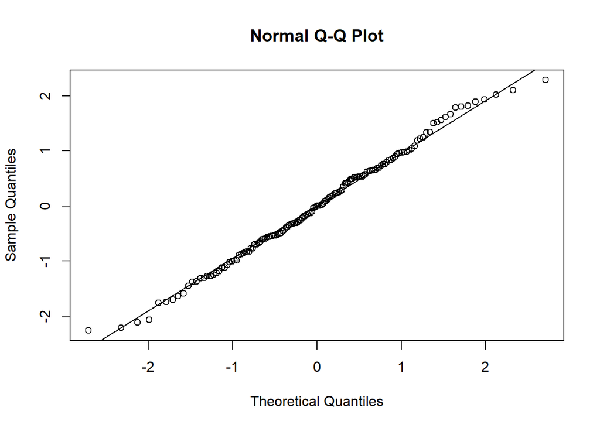

```r
qqnorm(resid(modeld))
qqline(resid(modeld))
```

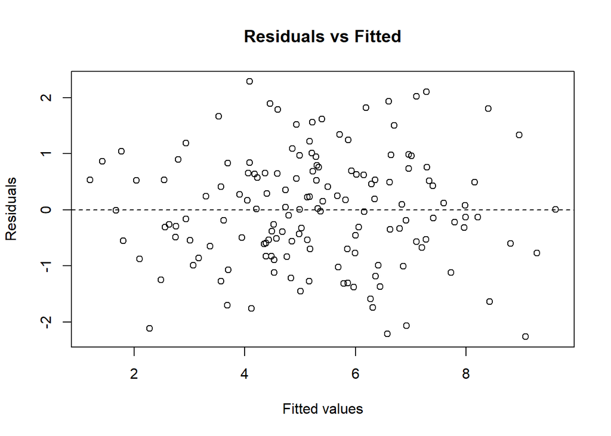

```r
plot(fitted(modeld), resid(modeld), xlab="Fitted values", ylab="Residuals", main="Residuals vs Fitted")
abline(h=0, lty="dashed")
```

**Q10. 1pt ✏️**

Do the assumptions appear to be met for this model? Briefly explain.

**Q11. 2pts ✏️**

Interpret the model output. What does the coefficient for IC represent? What do the coefficients for Dose represent? Which doses are significantly different from the control?

We can also run an ANOVA to test whether there is an overall effect of dose on final consumption:

```r
anova(modeld)
```

```
Analysis of Variance Table

Response: FC
           Df Sum Sq Mean Sq F value    Pr(>F)
IC          1 342.36  342.36 349.825 < 2.2e-16 ***
Dose        2 119.30   59.65  60.949 < 2.2e-16 ***
Residuals 146 142.89    0.98
---
Signif. codes:  0 '***' 0.001 '**' 0.01 '*' 0.05 '.' 0.1 ' ' 1
```

And if needed, we can do pairwise comparisons:

```r
emm.d<-emmeans(modeld, "Dose")
pairs(emm.d)
```

```
 contrast        estimate    SE  df t.ratio p.value
 control - dose1     0.44 0.200 146   2.199  0.0747
 control - dose2     2.10 0.202 146  10.412 <0.0001
 dose1 - dose2       1.66 0.198 146   8.377 <0.0001

P value adjustment: tukey method for comparing a family of 3 estimates
```

**Q12. 1pt ✏️**

Based on the pairwise comparisons, which doses are significantly different from each other?

Pretty cool! And kind of easy, right? The linear model framework works for categorical data (which is the same as t-tests and ANOVAs) AND for continuous data. The logic is always the same!

— End of assignment —